# CR_PMS_Bennasser_Hasbouni_Mouret

Bennasser, Hasbouni, Mouret

04/04/2025

# Le problème des chars d’assaut allemands

## Partie 1 - Tirage avec remise

On considère une variable aléatoire $X$ suivant une loi uniforme discrète sur $\{1, \dots, \theta\}$ et que pour tout $k \in \{1, \ldots, \theta\}$,
$$P(X=k ; \theta) = \frac{1}{\theta} \,
\mathbb{1}{\{1, \ldots, \theta\}}(k).$$

1. Calculer l’espérance et la variance de $X$.

$$E[X]=\sum_{k=1}^{\theta} kP(X=k;
\theta) = \sum_{k=1}^{\theta} k \frac{1}{\theta} = \frac{1}{\theta}
\frac{\theta(\theta+1)}{2}$$
$$\boxed{E[X]=\frac{\theta+1}{2}}$$

$$E[X^2] = \sum_{k=1}^{\theta} k^2 P(X=k;
\theta) = \frac{1}{\theta}\sum_{k=1}^{\theta} k^2 =
\frac{(\theta+1)(2\theta+1)}{6}$$
alors :
$$\begin{align*} Var[X] &=
\frac{(\theta+1)(2\theta+1)}{6} - \left(\frac{\theta+1}{2}\right)^2 \\
&= \frac{2(\theta+1)(2\theta+1)}{12} - \frac{3(\theta +1)^2}{12}\\
&= \frac{(\theta+1) [2(2\theta+1)-3(\theta+1)]}{12}\\
&= \frac{(\theta+1)(\theta-1)}{12}
\end{align*}$$
$$\boxed{Var[X]=\frac{\theta^2-1}{12}}$$

2. Calculer l’estimateur des moments $\tilde{\theta}_n$ de $\theta$. Montrer que cet estimateur est sans biais et calculer sa variance.

$X_1,...,X_n$ sont des réalisations indépendantes et de même loi ${\cal U}_{\{1,\ldots,\theta\}}$

D’après la méthode des moments:
$$\boxed{\tilde{\theta}_n = 2 \bar{X}_n -1 }\text{
,
} \bar{X}_n = \frac{1}{n} \sum_{i=1}^{n} X_i$$
De plus,

$$E[\tilde{\theta}_n] = E[2 \bar{X}_n -
1] = 2 E[\bar{X}_n] - 1$$
Or, $E[\bar{X}_n] = E[X] = \frac{\theta + 1}{2}$, donc :

$$E[\tilde{\theta}_n] = 2 \times
\frac{\theta + 1}{2} - 1 = \theta$$

Ainsi, $\tilde{\theta}_n$ est un estimateur sans biais.

On a :
$$Var(\tilde{\theta}_n) = Var(2
\bar{X}_n - 1) = 4 Var(\bar{X}_n)$$

La variance de la moyenne empirique est :
$$Var(\bar{X}_n) = \frac{Var(X)}{n} =
\frac{\theta^2 - 1}{12n}$$

Donc :
$$\boxed{Var(\tilde{\theta}_n) = 4
\times \frac{\theta^2 - 1}{12n} = \frac{\theta^2 - 1}{3n}}$$

3. Calculer la fonction de répartition de $X$. Calculer la médiane de la loi de $X$ et en déduire un estimateur $\tilde{\theta}'_n$ de $\theta$ basé sur la médiane empirique.
- Fonction de répartition de $X$:
  $$F_X(x)=P(X
  \le x)=
  \begin{cases}
  0, & \text{si } x \le 0 \\
  \sum_{k=1}^{x} P(X=k) = \frac{x}{\theta}, & \text{si } 0 \le x
  \le\theta \\
  1,& \text{si } x\geq \theta
  \end{cases}$$
- Mediane de X:

  $mediane(X)= \frac{\theta+1}{2}$
- Estimateur $\tilde{\theta}'_n$:

On en déduit $\tilde{\theta}'_n$ = $2mediane(X)-1$

$$\begin{align*}
L(\theta;x_1,...,x_n) &= \prod_{i=1}^{n}P(X=x_i; \theta) \\
&=\prod_{i=1}^{n} \frac{1}{\theta} \mathbb{1}_{1\le x_i \le
\theta} \\
&= \frac{\mathbb{1}_{max\{X_i\}\le\theta}}{\theta^n}
\end{align*}$$
$L(\theta;x_1,...,x_n)$ étant décroissante, on cherche à minimiser $\theta$ tel que $\theta \ge X_i^*$ .

6. Expliquer comment construire le graphe de probabilités pour la loi uniforme discrète. En déduire un estimateur graphique $\theta_g$ de $\theta$.

La fonction de répartition est une fonction affine avec de pente $\frac1\theta$ et passant par l’origine. On peut ainsi faire une régression linéaire et estimer $\theta_{graphique} = \frac1{pente}$ .

7. Simuler un échantillon de taille $n=100$ d’une loi ${\cal U}_{\{1,\ldots,\theta\}}$, avec $\theta=1000$. Tracer un histogramme et le graphe de probabilités pour la loi uniforme discrète. Calculez les 5 estimations de $\theta$. Commentez les résultats.

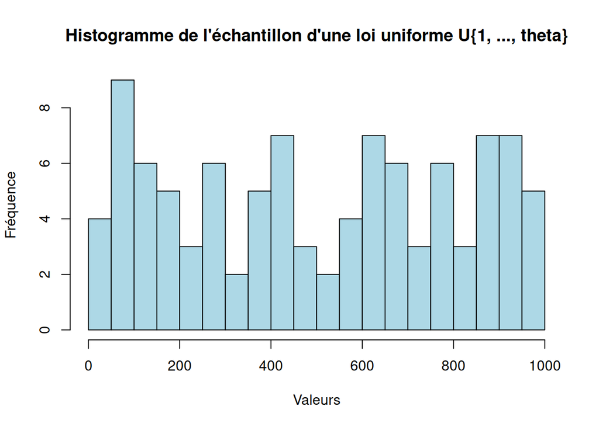

```r
# Simulation d'un échantillon de taille n=100 d'une loi uniforme U{1, ..., theta}
n <- 100
theta <- 1000
echantillon <- sample(1:theta,n,replace=T)


# Histogramme de l'échantillon
hist(echantillon, breaks = 20,col = "lightblue",
     main = "Histogramme de l'échantillon d'une loi uniforme U{1, ..., theta}", xlab = "Valeurs", ylab = "Fréquence")
```

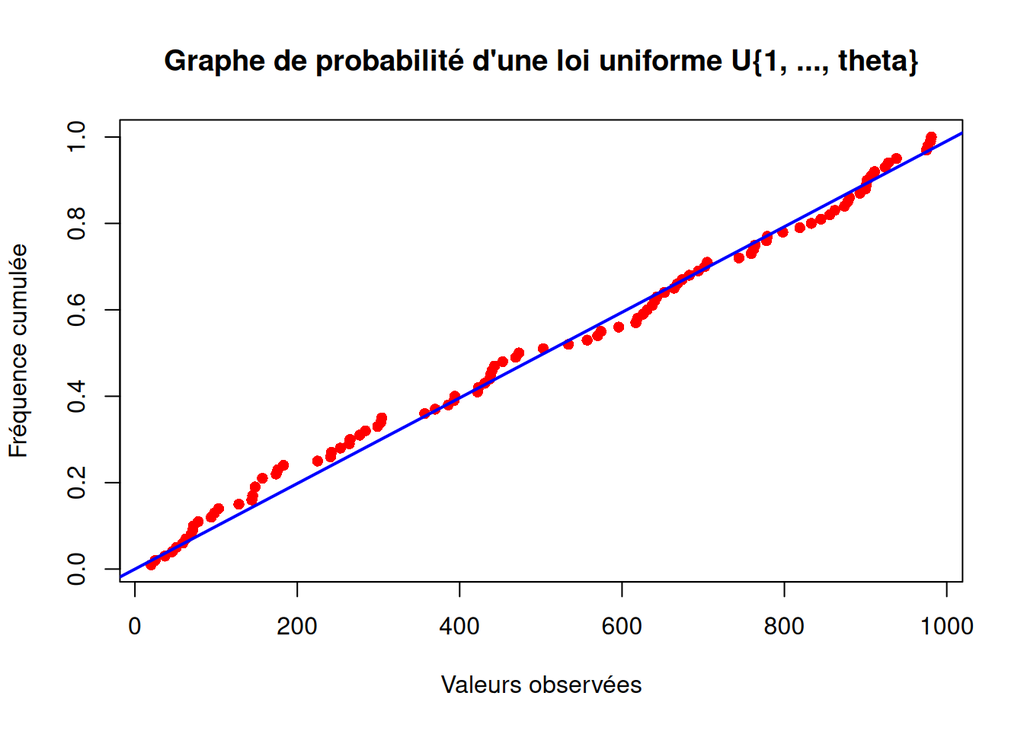

```r
# Graphe de probabilité
valeurs_uniques <- sort(unique(echantillon))
freqs_cumul <- cumsum(table(echantillon) / n)

plot(valeurs_uniques, freqs_cumul, type = "p", col = "red", pch = 16,
     main = "Graphe de probabilité d'une loi uniforme U{1, ..., theta}",
     xlab = "Valeurs observées", ylab = "Fréquence cumulée")

modele <- lm(freqs_cumul ~ valeurs_uniques - 1)  # Régression linéaire
abline(modele, col = "blue", lwd = 2)
```

```r
# Estimations de theta
theta_moment <- 2*mean(echantillon) -1
theta_mediane <- 2* median(echantillon) -1
theta_max <- max(echantillon)
theta_graphique <- as.numeric(1/coef(modele))  # On récupère la valeur de la pente
theta_corrige <- ((theta_max)^(n+1) - (theta_max -1)^(n+1))/((theta_max)^n - (theta_max-1)^n)

theta_values <- c(
  "theta_moment" = theta_moment,
  "theta_mediane" = theta_mediane,
  "theta_max" = theta_max,
  "theta_graphique" = theta_graphique,
  "theta_corrige" = theta_corrige
)

print(theta_values)
```

```
##    theta_moment   theta_mediane       theta_max theta_graphique   theta_corrige
##       1003.8800        975.0000        981.0000       1009.5339        990.3135
```

8.Simuler $m=1000$ échantillons de taille $n$ d’une loi ${\cal U}_{\{1,\ldots,\theta\}}$, avec $\theta=1000$. Pour chaque échantillon, calculer les valeurs des 5 estimations de $\theta$. On obtient ainsi des échantillons de $m$ valeurs de chacun des 5 estimateurs. Evaluer le biais et l’erreur quadratique moyenne de ces estimateurs. Faites varier $n$. Qu’en concluez-vous ?

```r
m <- 1000
n <- 100
theta <- 1000

# Matrices pour stocker les estimateurs
theta_moment <- numeric(m)
theta_mediane <- numeric(m)
theta_max <- numeric(m)
theta_graphique <- numeric(m)
theta_corrige <- numeric(m)

# Simulation
for (i in 1:m) {
  echantillon <- sample(1:theta,n,replace=T)

  valeurs_uniques <- sort(unique(echantillon))
  freqs_cumul <- cumsum(table(echantillon) / n)

  modele <- lm(freqs_cumul ~ valeurs_uniques - 1)  # Régression linéaire

  # Estimations de theta
  theta_moment[i] <- 2*mean(echantillon) -1
  theta_mediane[i] <- 2* median(echantillon) -1
  theta_max[i] <- max(echantillon)
  theta_graphique[i] <- as.numeric(1/coef(modele))  # On récupère la valeur de la pente
  theta_corrige[i] <- ((theta_max[i])^(n+1) - (theta_max[i] -1)^(n+1))/((theta_max[i])^n - (theta_max[i]-1)^n)
}


# Fonction pour calculer le biais et l'EQM de chaque estimateur
calcul_biais_EQM <- function(estimateur) {
  biais <- mean(estimateur) - theta
  eqm <- mean((estimateur - theta)^2)
  return(c(Biais = biais, EQM = eqm))
}

stats_moment <- calcul_biais_EQM(theta_moment)
stats_mediane <- calcul_biais_EQM(theta_mediane)
stats_max <- calcul_biais_EQM(theta_max)
stats_graphique <- calcul_biais_EQM(theta_graphique)
stats_corrige <- calcul_biais_EQM(theta_corrige)

# Résultats sous forme de tableau
results <- rbind(
  Moment = stats_moment,
  Mediane = stats_mediane,
  Maximum = stats_max,
  Graphique = stats_graphique,
  Corrige = stats_corrige
)

print(results)
```

```
##                Biais       EQM
## Moment     0.2365000  3455.578
## Mediane    2.7140000 10119.334
## Maximum   -9.2110000   185.645
## Graphique -6.7766592  2097.069
## Corrige    0.2003037   102.867
```

Les autres estimateurs ont aussi un biais très faible mais conservent une EQM élevée par rapport à $\check{\theta}_n$ et $\hat{\theta}_n$.

9. Déterminer un intervalle de confiance asymptotique de seuil $\alpha$ pour $\theta$ c’est-à-dire un intervalle aléatoire $I_n$ tel que $\lim_{n \rightarrow \infty} P(\theta \in I_n)=1-\alpha.$ Calculer l’intervalle de confiance asymptotique de seuil 5% pour les données simulées dans la question 7.

D’après le TCL :
$$\sqrt{n}\frac{\bar X_n
- \frac{(\theta+1)}{2}}{S_n'} \rightarrow \mathcal{N}(0,\,1)$$

Alors,
$$P\left(\left\lvert\sqrt{n}\frac{\bar X_n -
\frac{(\theta+1)}{2}}{S_n'}\right\rvert\le U_\alpha\right) =
1-\alpha$$

Or
$$\left\lvert\sqrt{n}\frac{\bar X_n -
\frac{(\theta+1)}{2}}{S_n'}\right\rvert \le U_\alpha
\Leftrightarrow \frac{n^2}{4}\theta^2+(\frac{1}{2}-\bar X_n)n²
\theta+n²(\bar X_n^2-\bar X_n +\frac14)-U^2_\alpha n S_n'^2 \le 0$$
$$\Delta =
n³U_{\alpha}^2S_n'^2$$
les racines du polynomes sont alors :
$$2\bar X_n-1 \pm \frac{2}{n^2}\sqrt\Delta = \tilde{\theta}_n\pm 2
\frac{U_\alpha S_n'}{\sqrt n}$$

L’intervalle de confiance est donc :

$$IC = \left[\tilde{\theta}_n- 2 \frac{U_\alpha S_n'}{\sqrt
n},\tilde{\theta}_n+ 2 \frac{U_\alpha S_n'}{\sqrt n}\right]$$

```r
n <- 100
alpha <- 0.05
U_alpha <- qnorm(1 - alpha/2)  # Quantile de la loi normale

theta <- 1000
echantillon <- sample(1:theta, n, replace = T)

# Calcul de la moyenne et de l'écart-type empirique
mean_X <- mean(echantillon)
sd_X <- sd(echantillon)

# Calcul de theta_moment
theta_moment <- 2 * mean_X - 1

# Calcul de l'intervalle de confiance
IC_bas <- theta_moment - 2 * (U_alpha * sd_X / sqrt(n))
IC_haut <- theta_moment + 2 * (U_alpha * sd_X / sqrt(n))

# Affichage des résultats
cat("Intervalle de confiance à 95%: [", IC_bas, ",", IC_haut, "]\n")
```

```
## Intervalle de confiance à 95%: [ 953.4121 , 1178.428 ]
```

10. Simuler $m=1000$ échantillons de taille $n$ d’une loi ${\cal U}_{\{1,\ldots,\theta\}}$, pour $n=10$ et $n=1000$. Calculer le pourcentage de fois où l’intervalle de confiance de seuil $\alpha$ pour $\theta$ contient la vraie valeur du paramètre $\theta$. Faire varier $\alpha$ et conclure.

```r
m <- 1000
n_values <- c(10, 1000)
alpha_values <- c(0.01, 0.05, 0.1)
theta <- 1000

# Fonction pour estimer theta et vérifier si l'intervalle de confiance contient theta
calcul_IC <- function(n, alpha) {
  U_alpha <- qnorm(1 - alpha/2)  # Quantile de la loi normale
  cpt <- 0

  for (i in 1:m) {
    echantillon <- sample(1:theta, n, replace = T)
    mean_X <- mean(echantillon)
    sd_X <- sd(echantillon)
    theta_moment <- 2 * mean_X - 1

    IC_bas <- theta_moment - 2 * (U_alpha * sd_X / sqrt(n))
    IC_haut <- theta_moment + 2 * (U_alpha * sd_X / sqrt(n))

    if (IC_bas <= theta && theta <= IC_haut) {
      cpt <- cpt + 1
    }
  }

  return(cpt / m * 100)
}

# Simulation pour différentes valeurs de n et alpha
results <- expand.grid(n = n_values, alpha = alpha_values)
results$Pourcentage <- mapply(calcul_IC, results$n, results$alpha)

# Affichage des résultats
print(results)
```

```
##      n alpha Pourcentage
## 1   10  0.01        96.0
## 2 1000  0.01        99.5
## 3   10  0.05        91.5
## 4 1000  0.05        94.1
## 5   10  0.10        88.9
## 6 1000  0.10        90.8
```

Plus le nombre de données augmente, plus la probabilité que $\theta$ soit contenu dans l’intervalle de confiance augmente. De même, plus $\alpha$ est petit, plus l’intervalle de confiance est large.

## Partie 2 - Tirage sans remise

## Lois des estimateurs et EMV

### 1. Lois des variables

Pour un tirage sans remise de $n$ chars parmi $\theta$ :

- **Loi du premier char** ($X_1$) :
  $$P(X_1 = x_1) = \frac{1}{\theta},\quad x_1
  \in \{1,...,\theta\}$$

  Chaque char a la même probabilité d’être tiré initialement.
- **Loi du deuxième char** ($X_2$) :
  $$P(X_2 = x_2) = \frac{1}{\theta -1}, \quad
  x_2 \in \{1,...,\theta\}\setminus\{x_1\}$$

  Après avoir tiré le premier char, il reste $\theta-1$ possibilités équiprobables.
- **Loi conditionnelle générale** :
  $$P(X_k = x_k | X_1,...,X_{k-1}) =
  \frac{1}{\theta - k + 1}$$

  À chaque étape, on retire un char du pool possible.

### 2. Estimateur du Maximum de Vraisemblance (EMV)

La fonction de vraisemblance :

$$L(\theta; x_1,...,x_n) = \prod_{k=1}^n
P(X_k=x_k) = \frac{(\theta-n)!}{\theta!}$$

$L(\theta) = 0$ si $\theta < X_n^*$ (incompatible avec l’observation):

Pour $\theta \geq X_n^*$, $L(\theta)$ est strictement décroissante

donc ; L’EMV est $\hat\theta_n = X_n^* = \max(X_1,...,X_n)$.

## Loi de $X_n^*$

### Démonstration de la loi

Pour $k \in \{n,...,\theta\}$ :

$$P(X_n^* = k) =
\frac{\binom{k-1}{n-1}}{\binom{\theta}{n}}$$

- Au dénominateur : tous les échantillons possibles ($\binom{\theta}{n}$)
- Au numérateur : échantillons où le max vaut exactement $k$

### Calcul de l’espérance

En utilisant l’identité combinatoire :

$$\sum_{k=n}^\theta \binom{k}{n} =
\binom{\theta+1}{n+1}$$

On obtient après simplification :

$$E[X_n^*] =
\frac{n(\theta+1)}{n+1}$$

## Les quatres estimateurs

### 1. EMV (biaisé)

$$\hat\theta_{EMV} = X_n^*$$

Biais : $E[\hat\theta_{EMV}] - \theta = -\frac{\theta}{n+1}$

### 2. EMVSB (sans biais)

$$\hat\theta_{EMVSB} = \frac{n+1}{n}X_n^*
- 1$$

Corrige exactement le biais.

### 3. Estimateur symétrique

$$\hat\theta_{sym} = X_n^* + X_1^* -
1$$

Biais résiduel (ne depend pas de $\theta$) : $\frac{n-1}{n+1}$

### 4. Estimateur par Remise

L’estimateur par remise est donné par :

$$\theta_{remise} = \frac{X_n^{*(n+1)} -
(X_n^* - 1)^{n+1}}{X_n^{*n} - (X_n^* - 1)^n}$$

où $X_n^* = \max(X_1,...,X_n)$ est la valeur maximale observée.

## Analyse pour n = 5

| Estimateur | Moyenne | Biais | Variance |
| --- | --- | --- | --- |
| EMV | 84.39 | -15.61 | 203.23 |
| EMVSB | 100.27 | 0.27 | 292.65 |
| Symétrique | 102.39 | 2.39 | 526.87 |
| Avec remise | 100.67 | 0.67 | 292.61 |

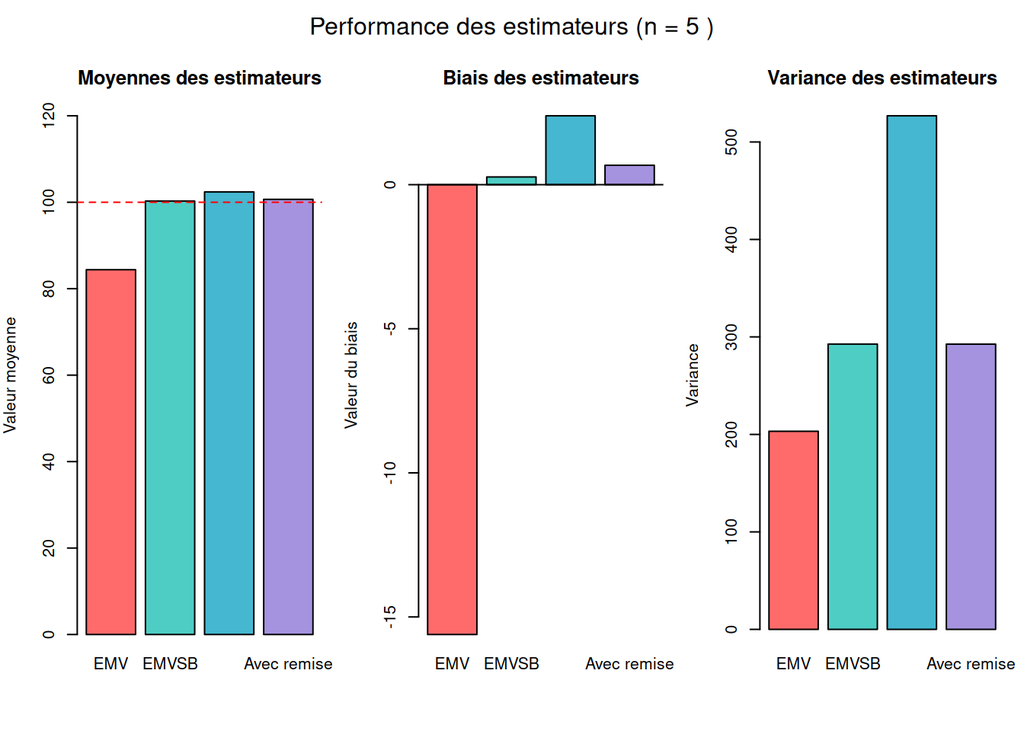

| Estimateur | Moyenne | Biais | Variance |
| --- | --- | --- | --- |
| EMV | 95.20 | -4.80 | 25.19 |
| EMVSB | 100.55 | 0.55 | 28.66 |
| Symétrique | 101.18 | 1.18 | 56.57 |
| Avec remise | 101.03 | 1.03 | 28.65 |

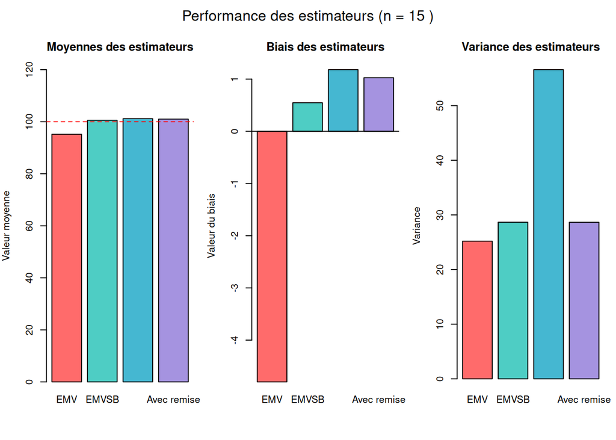

# ————————————————–

# COMPARAISON DES ESTIMATEURS AVEC ET SANS REMISE

# ————————————————–

```r
getwd()
```

```
## [1] "/home/rstudio"
```

```r
iPhones <- read.table("iPhones.csv", sep=";", header=T)
names(iPhones)
```

```
## [1] "IMEI" "PC"
```

```r
attach(iPhones)


TAC <- data.frame(
  Code_TAC = c(161200, 161300, 161400, 171200, 171300, 171400, 174200, 174300,
               174400, 177100, 177300, 177400, 177500, 177600, 180900),
  Numero_TAC = c(1, 2, 3, 4, 5, 6, 7, 8, 9, 10, 11, 12, 13, 14, 15)
)

iPhones$Code_TAC <- as.numeric(substring(iPhones$IMEI, 3, 8))
iPhones <- merge(iPhones, TAC, by = "Code_TAC", all.x=TRUE)
iPhones$SNR <- as.numeric(substring(iPhones$IMEI, 9, 13))*10
iPhones$NS <- (iPhones$Numero_TAC - 1) * 10^6 + iPhones$SNR
```

## Question 2:

On utilise l’estimateur de l’exercice 2

```r
NS_max <- max(iPhones$NS, na.rm=TRUE)
n <- nrow(iPhones)
Nombre_iPhones <- ((n+1)/n) * NS_max-1
cat("La production totale est estimée à :", Nombre_iPhones, "\n")
```

```
## La production totale est estimée à : 14887670
```

## Question 3:

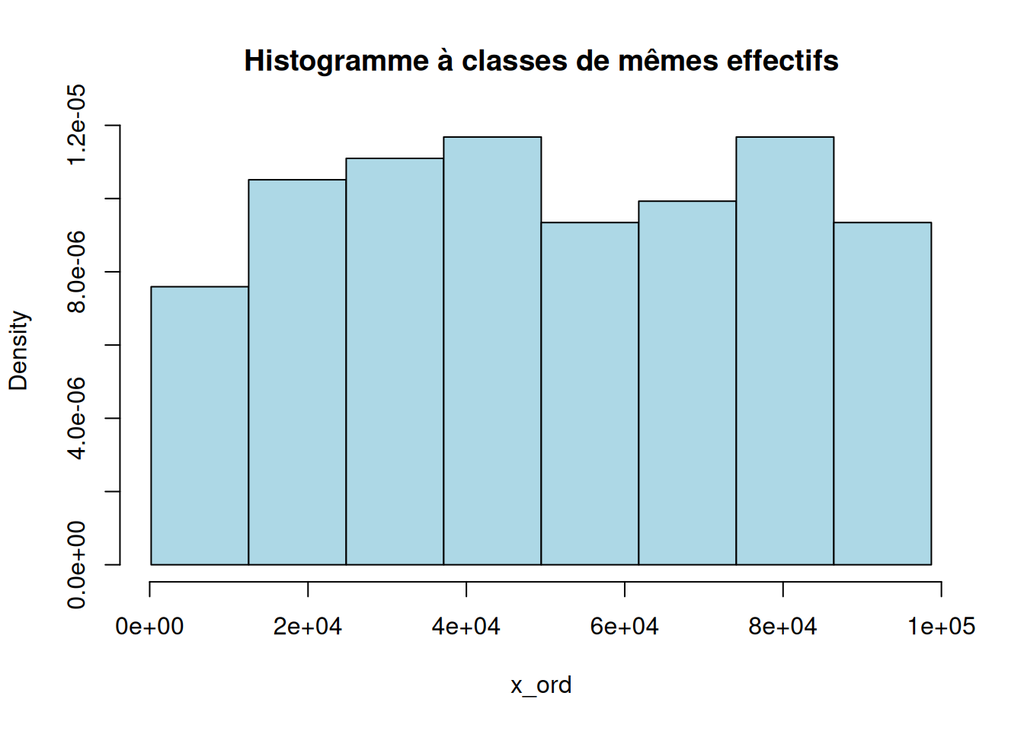

```r
x <- as.numeric(substring(iPhones$IMEI, 8, 13))
x_ord <- sort(x)

a0 <- min(x_ord) - 100
an <- max(x_ord) + 100

n <- 8
bornes <- seq(a0, an, length.out = n + 1)

# 4. Plot the histogram
hist(x_ord,
     breaks = bornes,
     prob = TRUE,
     main = "Histogramme à classes de mêmes effectifs",
     col = "lightblue",
     border = "black",
     xlim = c(a0, an))
```

L’histogramme ne permet pas de conclure, on utilise donc le test de Kolmogorov-Smirnov:

```r
ks_test <- ks.test(x, "punif", min(x), max(x))
print(ks_test)
```

```
##
##  Asymptotic one-sample Kolmogorov-Smirnov test
##
## data:  x
## D = 0.047256, p-value = 0.9155
## alternative hypothesis: two-sided
```

$p-value > 0.05$ donc on ne peut pas rejeter l’hypothèse d’uniformité.

On suppose que la distribution des numéros de série est uniforme, alors qu’en pratique, il se peut que différentes plages de numéros de série soient utilisées par différentes régions, usines ou périodes. Ainsi, la répartition uniforme peut ne pas refléter fidèlement la réalité de la gestion des numéros de série et il faut examiner les méthodes plus précisément afin de pouvoir confirmer ou rejeter l’hypothèse d’uniformité.

## Question 4:

Pour estimer la production par périodes de 4 semaines, on regroupe les données par paquets de 4 semaines et on estime le nombre d’appareils produits pour chaque groupe en appliquant le deuxième estimateur à NS, et en soustrayant à chaque résultat le précédent pour obtenir la production par tranche.